# SidharthJadli32014252

Siddharth Jadli

2024-06-02

# Task 1 (2 Marks) & Task 2 (3 Marks)

In these tasks I collected a set of machine-readable text documents from a few areas of my interest. My favourite interests lie in William Shakespeare’s Literature, Pop Smoke’s Hip-Hop/Rap music and 2 of my favourite sports - Tennis and Formula 1.

All of my sources are listed below in APA Style -

In-text citation: For “The Tragedy of Julius Caesar” (Shakespeare, 1599) and “The Tragedy of Romeo and Juliet” (Shakespeare, 1594):

Reference list: Shakespeare, W. (1599, 1594). The tragedy of Julius Caesar and The Tragedy of Romeo and Juliet. Open Source Shakespeare. Retrieved from [https://www.opensourceshakespeare.org/]

In-text citation: For lyrics from the song “Dior” (Pop Smoke, 2019), “Merci Beaucoup” (Pop Smoke, 2021), “Element” (Pop Smoke, 2020) and “Christopher Walking” (Pop Smoke, 2020):

Reference list: Pop Smoke. (2019, 2021, 2020). Dior, Merci Beaucoup, Christopher Walking. Genius. Retrieved from [https://genius.com/Pop-smoke-dior-lyrics, https://genius.com/Pop-smoke-merci-beaucoup-lyrics, https://genius.com/Pop-smoke-element-lyrics, https://genius.com/Pop-smoke-christopher-walking-lyrics]

In-text citation: For quotes from the press conference transcript (Fédération Internationale de l’Automobile, 2024):

Reference list: Fédération Internationale de l’Automobile. (2024). F1 2024 Monaco Grand Prix post-race press conference transcript. Retrieved from [https://www.fia.com/news/f1-2024-monaco-grand-prix-post-race-press-conference-transcript]

In-text citation: For quotes from the press conference transcripts (ASAP Sports, 2024):

Reference list: ASAP Sports. (2024). Rolland Garros Press conference transcripts. Retrieved from [https://www.asapsports.com/show_event.php?category=7&date=2024-5-25&title=ROLAND+GARROS]

I copied and pasted these texts into a txt file. I also made sure that each file was ran through a profanity detector and ommited and flagged profanities. Since I had some domain knowledge regarding the areas of interest I had some preemption that the usage of words within each domain would be similar, which would lead to a good clustering model built on top of the bag of words model that we will use for this assignment.

These txt files were placed in one folder, and I put labels in each file name (Literature, Music or Sport)

# Task 3: DTM (3 Marks)

We will initialize the assignment by removing all objects from the current workspace and setting the working directory to the correct address in my local machine; loading necessary packages and initializing the corpus with the docs variable

```r
# Set working directory to desktop
setwd("/Users/Sid/Desktop/Monash/FIT3152/Ass03")

# Cleaning up the environment before starting
rm(list = ls())

set.seed(32014252) # Setting seed for reproducability

# LIBRARIES
library(tm)
library(slam)       # Matrices and arrays
library(SnowballC)  # Stemming
library(proxy)      # Cosine distances
```

```r
library(igraph)     # Graph analysis
library(igraphdata) # Graph analysis

# Get file path to folder "Corpus" where the documents are located
cname = file.path(".", "Corpus")
docs = Corpus(DirSource((cname)))
print(summary(docs))
```

```
##                                             Length Class             Mode
## Act I Sc 5 - R & J (Lit).txt                2      PlainTextDocument list
## Act II, Sc 1 - JC (Lit).txt                 2      PlainTextDocument list
## Act II, Sc 2 - R & J (Lit).txt              2      PlainTextDocument list
## Act III, Sc 1 - J C (Lit).txt               2      PlainTextDocument list
## Act III, Sc 2 - J C (Lit).txt               2      PlainTextDocument list
## Act V, Sc 3 - R & J (Lit).txt               2      PlainTextDocument list
## Christopher Walking - Pop Smoke (Music).txt 2      PlainTextDocument list
## CL - F1 (Sport).txt                         2      PlainTextDocument list
## CS - F1 (Sport).txt                         2      PlainTextDocument list
## Dior - Pop Smoke (Music).txt                2      PlainTextDocument list
## Element - Pop Smoke (Music).txt             2      PlainTextDocument list
## Elena Rybanika - Tennis (Sport).txt         2      PlainTextDocument list
## Gael Monfils - Tennis (Sport).txt           2      PlainTextDocument list
## Merci Beaucoup - Pop Smoke (Music).txt      2      PlainTextDocument list
## OP - F1 (Sport).txt                         2      PlainTextDocument list
## Rafael Nadal - Tennis (Sport).txt           2      PlainTextDocument list
```

Now that we have retrieved the documents, we will tokenise our data by processing it and create the document term matrix (DTM). First I will perform some text transformations which I was able to observe in the lyrics of the music, remove punctuations, numbers, white space, stop words and convert to lower case. We will then stem the words to convert them to their root form.

```r
# Text transformations, ref Williams
text_transformation <- content_transformer(function(x, pattern, replacement) {
  gsub(pattern, replacement, x, ignore.case = TRUE)
})

docs <- tm_map(docs, content_transformer(tolower))      # converting to lower case

# Apply the custom transformation to the corpus
corpus <- tm_map(docs, text_transformation, "sayin'", "saying")
corpus <- tm_map(docs, text_transformation, "poppin'", "popping")
corpus <- tm_map(docs, text_transformation, "grabbin'", "grabbing")
corpus <- tm_map(docs, text_transformation, "talkin'", "talking")
corpus <- tm_map(docs, text_transformation, "shoppin'", "shopping")
corpus <- tm_map(docs, text_transformation, "makin'", "making")
corpus <- tm_map(docs, text_transformation, "gon'", "gonna")
corpus <- tm_map(docs, text_transformation, "drownin'", "drowning")
corpus <- tm_map(docs, text_transformation, "hunnid", "hundred")
corpus <- tm_map(docs, text_transformation, "budgin'", "budging")
corpus <- tm_map(docs, text_transformation, "gassin'", "gassing")
corpus <- tm_map(docs, text_transformation, "pumpin", "pumping")
corpus <- tm_map(docs, text_transformation, "opp", "opposition")
corpus <- tm_map(docs, text_transformation, "lackin'", "lacking")
corpus <- tm_map(docs, text_transformation, "feelin'", "feeling")
corpus <- tm_map(docs, text_transformation, "'cause", "because")
corpus <- tm_map(docs, text_transformation, "suckin'", "sucking")
corpus <- tm_map(docs, text_transformation, "screamin'", "screaming")
corpus <- tm_map(docs, text_transformation, "throwin'", "throwing")
corpus <- tm_map(docs, text_transformation, "wildin'", "wilding")
corpus <- tm_map(docs, text_transformation, "raisin'", "raising")
corpus <- tm_map(docs, text_transformation, "doin", "doing")
corpus <- tm_map(corpus, text_transformation, "takin'", "taking")
corpus <- tm_map(corpus, text_transformation, "hol", "hold")
corpus <- tm_map(corpus, text_transformation, "'Rari", "ferrari")
corpus <- tm_map(corpus, text_transformation, "Saucin'", "saucing")
corpus <- tm_map(corpus, text_transformation, "nothin'", "nothing")
corpus <- tm_map(corpus, text_transformation, "whatchu", "what you")
corpus <- tm_map(corpus, text_transformation, "somethin'", "something")
corpus <- tm_map(corpus, text_transformation, "winnin'", "winning")


docs <- tm_map(docs, removeNumbers)                     # removing numbers
docs <- tm_map(docs, removePunctuation)                 # removing punctuations
docs <- tm_map(docs, removeWords, stopwords("english")) # removing stop words
docs <- tm_map(docs, stripWhitespace)                   # removing white space

docs <- tm_map(docs, stemDocument, language = "english") # stemming

# Create document term matrix
dtm <- DocumentTermMatrix(docs)
inspect(dtm)
```

```
## <<DocumentTermMatrix (documents: 16, terms: 2653)>>
## Non-/sparse entries: 5519/36929
## Sparsity           : 87%
## Maximal term length: 15
## Weighting          : term frequency (tf)
## Sample             :
##                                    Terms
## Docs                                brutus caesar come know like romeo shall
##   Act I Sc 5 - R & J (Lit).txt           0      0    9    3    3    13     6
##   Act II, Sc 1 - JC (Lit).txt           61     18    6   10    4     0    15
##   Act II, Sc 2 - R & J (Lit).txt         0      0    4    3    3    40     6
##   Act III, Sc 1 - J C (Lit).txt         47     59   10   10    4     0    34
##   Act III, Sc 2 - J C (Lit).txt         38     49   14   12    1     0     9
##   Act V, Sc 3 - R & J (Lit).txt          0      0   20    6    0    25     7
##   CL - F1 (Sport).txt                    0      0    3    7   17     0     0
##   CS - F1 (Sport).txt                    0      0    2    5   13     0     0
##   Gael Monfils - Tennis (Sport).txt      0      0    2   16    5     0     0
##   Rafael Nadal - Tennis (Sport).txt      0      0    2   12    7     0     0
##                                    Terms
## Docs                                think thou will
##   Act I Sc 5 - R & J (Lit).txt          1    4    7
##   Act II, Sc 1 - JC (Lit).txt           8    9   21
##   Act II, Sc 2 - R & J (Lit).txt        2   32    8
##   Act III, Sc 1 - J C (Lit).txt         1   12   14
##   Act III, Sc 2 - J C (Lit).txt         0    5   40
##   Act V, Sc 3 - R & J (Lit).txt         3   21   18
##   CL - F1 (Sport).txt                  26    0    8
##   CS - F1 (Sport).txt                  15    0    5
##   Gael Monfils - Tennis (Sport).txt     6    0    4
##   Rafael Nadal - Tennis (Sport).txt    10    0   10
```

We have 2653 terms in our DTM containing 16 documents has a high sparcity (87%). Now we will remove sparce terms (I tried various combinations of thresholds and 0.4 was gave me the best results)

```r
# Remove sparse terms
dtms <- removeSparseTerms(dtm, 0.4)  # Remove columns with 40% empty (0) cells
inspect(dtms)
```

```
## <<DocumentTermMatrix (documents: 16, terms: 39)>>
## Non-/sparse entries: 463/161
## Sparsity           : 26%
## Maximal term length: 6
## Weighting          : term frequency (tf)
## Sample             :
##                                    Terms
## Docs                                come good know let like one think time well
##   Act I Sc 5 - R & J (Lit).txt         9    6    3   6    3   3     1    1    2
##   Act II, Sc 1 - JC (Lit).txt          6   10   10  15    4   7     8    3    7
##   Act II, Sc 2 - R & J (Lit).txt       4    9    3   4    3   2     2    3    2
##   Act III, Sc 1 - J C (Lit).txt       10    5   10   8    4   4     1    5    6
##   Act III, Sc 2 - J C (Lit).txt       14    5   12  15    1   0     0    1   12
##   Act V, Sc 3 - R & J (Lit).txt       20    5    6   5    0   5     3    5    2
##   CL - F1 (Sport).txt                  3    8    7   1   17  10    26   10    9
##   CS - F1 (Sport).txt                  2    7    5   2   13   8    15    4    3
##   Gael Monfils - Tennis (Sport).txt    2   10   16   0    5   3     6   11   21
##   Rafael Nadal - Tennis (Sport).txt    2    1   12   2    7   9    10   12    4
##                                    Terms
## Docs                                will
##   Act I Sc 5 - R & J (Lit).txt         7
##   Act II, Sc 1 - JC (Lit).txt         21
##   Act II, Sc 2 - R & J (Lit).txt       8
##   Act III, Sc 1 - J C (Lit).txt       14
##   Act III, Sc 2 - J C (Lit).txt       40
##   Act V, Sc 3 - R & J (Lit).txt       18
##   CL - F1 (Sport).txt                  8
##   CS - F1 (Sport).txt                  5
##   Gael Monfils - Tennis (Sport).txt    4
##   Rafael Nadal - Tennis (Sport).txt   10
```

We can see observe that sparcity has reduced to 26% and we have 39 terms in our DTM

```r
dtms = as.matrix(dtms)
write.csv(dtms, "dtms.csv")
```

# Task 4: Hierarchical Clustering (4 Marks)

Now we will performing clustering using cosine distances on our DTM.

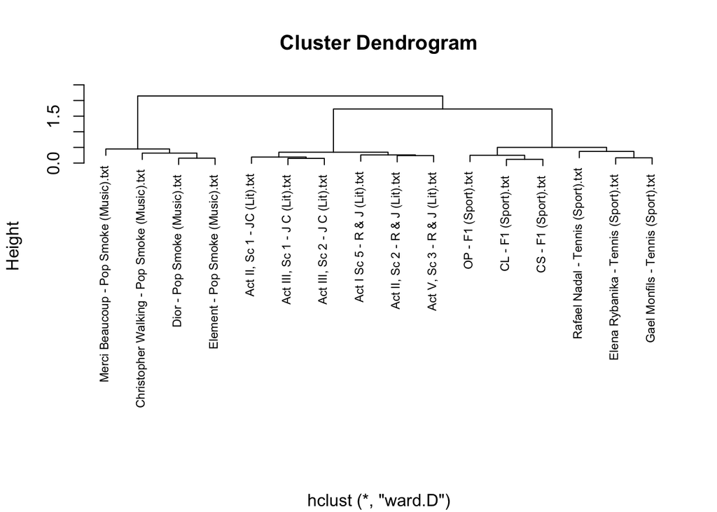

```r
# Clustering
set.seed(32014252) # keep clustering consistent

distmatrix = proxy::dist(dtms, method = "cosine")
fit = hclust(distmatrix, method = "ward.D")
plot(fit, xlab = "", cex = 0.7)
```

We can see that our clustering has clustered Literature, Music and Sport in their respective branches and the further branches down to show similarity within each groups (More similar documents are branching down together, i.e, Act III Sc 1 from Julius Ceaser and Act III Sc 2 from Julius Ceaser are very similar compared to Act II Sc 1 from Julius Ceaser). Now we will find the accuracy of our clustering model, which should be a 100% by looking at the plot above.

```r
# Vector of topic labels in same order as corpus
topics = c("Lit","Lit","Lit", "Lit", "Lit", "Lit",
            "Music", "Sport", "Sport", "Music", "Music", "Sport", "Sport", "Music", "Sport",
            "Sport")

groups = cutree(fit, k = 3) # vector of cluster numbers

# create matrix and reorder columns
TA = as.data.frame.matrix(table(GroupNames = topics, Clusters = groups))
TA
```

```
##       1 2 3
## Lit   6 0 0
## Music 0 4 0
## Sport 0 0 6
```

We can see that the model has clustered all the documents correctly where group 1 is Literature, group 2 is Music and group 3 is Sport.

# Task 5: Documents single-mode network (4 Marks)

### Creating the network

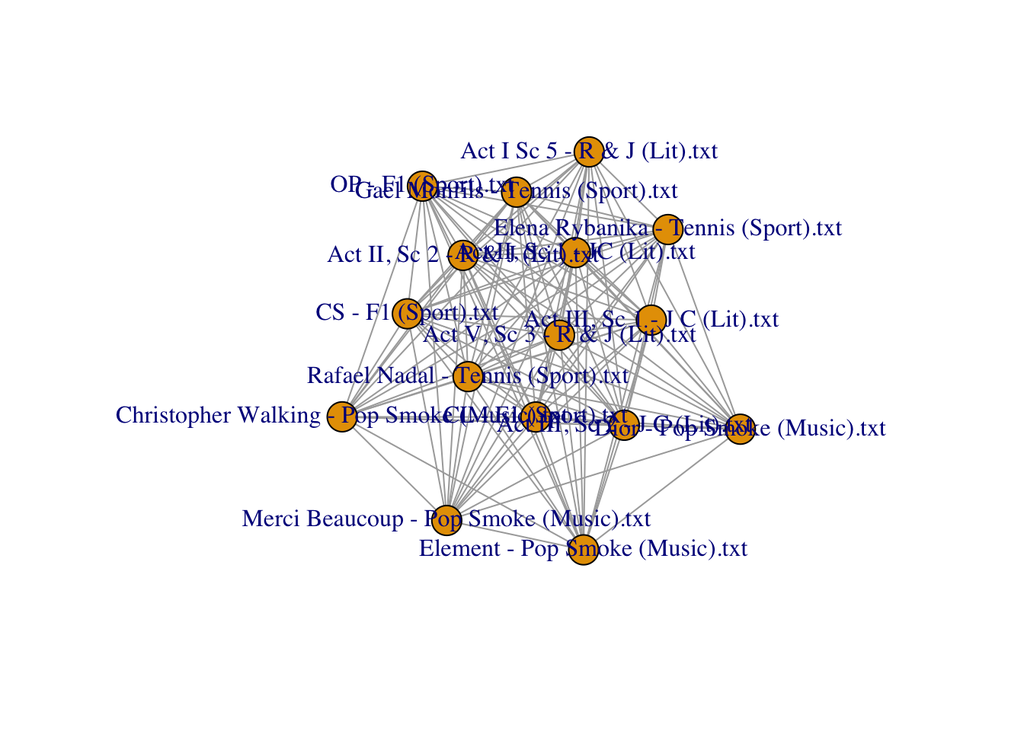

```r
# Convert original DTM to binary matrix
dtmsx = as.matrix(dtms)
dtmsx = as.matrix((dtmsx > 0) + 0)

# multiply binary matrix by its transpose
ByAbsMatrix = dtmsx %*% t(dtmsx)

# make leading diagonal zero
diag(ByAbsMatrix) = 0

# create graph object
ByAbs = graph_from_adjacency_matrix(ByAbsMatrix, mode = "undirected", weighted = TRUE)

set.seed(32014252) # keep clustering consistent
plot(ByAbs)
```

### Network Statistics

```r
# calculate network centrality measures and combine in a dataframe
d = as.table(degree(ByAbs))
b = as.table(betweenness(ByAbs))
c = as.table(closeness(ByAbs))
e = as.table(evcent(ByAbs)$vector)
stats = as.data.frame(rbind(d,b,c,e))
stats = as.data.frame(t(stats))
colnames(stats) = c("degree", "betweenness", "closeness", "eigenvector")

averagePath = average.path.length(ByAbs)
diameter = diameter(ByAbs)
```

```r
# sort and explore key nodes
stats[order(-stats$betweenness),]
```

```
##                                             degree betweenness   closeness
## Dior - Pop Smoke (Music).txt                    15  57.3333333 0.005847953
## Christopher Walking - Pop Smoke (Music).txt     15   5.8333333 0.005319149
## Element - Pop Smoke (Music).txt                 15   0.3333333 0.005076142
## Act I Sc 5 - R & J (Lit).txt                    15   0.0000000 0.003378378
## Act II, Sc 1 - JC (Lit).txt                     15   0.0000000 0.003021148
## Act II, Sc 2 - R & J (Lit).txt                  15   0.0000000 0.003164557
## Act III, Sc 1 - J C (Lit).txt                   15   0.0000000 0.003039514
## Act III, Sc 2 - J C (Lit).txt                   15   0.0000000 0.003496503
## Act V, Sc 3 - R & J (Lit).txt                   15   0.0000000 0.003039514
## CL - F1 (Sport).txt                             15   0.0000000 0.002881844
## CS - F1 (Sport).txt                             15   0.0000000 0.003246753
## Elena Rybanika - Tennis (Sport).txt             15   0.0000000 0.003448276
## Gael Monfils - Tennis (Sport).txt               15   0.0000000 0.003012048
## Merci Beaucoup - Pop Smoke (Music).txt          15   0.0000000 0.004854369
## OP - F1 (Sport).txt                             15   0.0000000 0.003448276
## Rafael Nadal - Tennis (Sport).txt               15   0.0000000 0.003105590
##                                             eigenvector
## Dior - Pop Smoke (Music).txt                  0.4067342
## Christopher Walking - Pop Smoke (Music).txt   0.4502777
## Element - Pop Smoke (Music).txt               0.4720321
## Act I Sc 5 - R & J (Lit).txt                  0.8136932
## Act II, Sc 1 - JC (Lit).txt                   0.9451682
## Act II, Sc 2 - R & J (Lit).txt                0.8042457
## Act III, Sc 1 - J C (Lit).txt                 0.9467589
## Act III, Sc 2 - J C (Lit).txt                 0.8048363
## Act V, Sc 3 - R & J (Lit).txt                 0.9147817
## CL - F1 (Sport).txt                           1.0000000
## CS - F1 (Sport).txt                           0.8756558
## Elena Rybanika - Tennis (Sport).txt           0.7981026
## Gael Monfils - Tennis (Sport).txt             0.9364633
## Merci Beaucoup - Pop Smoke (Music).txt        0.4893075
## OP - F1 (Sport).txt                           0.7651078
## Rafael Nadal - Tennis (Sport).txt             0.9366618
```

```r
stats[order(-stats$closeness),]
```

```
##                                             degree betweenness   closeness
## Dior - Pop Smoke (Music).txt                    15  57.3333333 0.005847953
## Christopher Walking - Pop Smoke (Music).txt     15   5.8333333 0.005319149
## Element - Pop Smoke (Music).txt                 15   0.3333333 0.005076142
## Merci Beaucoup - Pop Smoke (Music).txt          15   0.0000000 0.004854369
## Act III, Sc 2 - J C (Lit).txt                   15   0.0000000 0.003496503
## Elena Rybanika - Tennis (Sport).txt             15   0.0000000 0.003448276
## OP - F1 (Sport).txt                             15   0.0000000 0.003448276
## Act I Sc 5 - R & J (Lit).txt                    15   0.0000000 0.003378378
## CS - F1 (Sport).txt                             15   0.0000000 0.003246753
## Act II, Sc 2 - R & J (Lit).txt                  15   0.0000000 0.003164557
## Rafael Nadal - Tennis (Sport).txt               15   0.0000000 0.003105590
## Act III, Sc 1 - J C (Lit).txt                   15   0.0000000 0.003039514
## Act V, Sc 3 - R & J (Lit).txt                   15   0.0000000 0.003039514
## Act II, Sc 1 - JC (Lit).txt                     15   0.0000000 0.003021148
## Gael Monfils - Tennis (Sport).txt               15   0.0000000 0.003012048
## CL - F1 (Sport).txt                             15   0.0000000 0.002881844
##                                             eigenvector
## Dior - Pop Smoke (Music).txt                  0.4067342
## Christopher Walking - Pop Smoke (Music).txt   0.4502777
## Element - Pop Smoke (Music).txt               0.4720321
## Merci Beaucoup - Pop Smoke (Music).txt        0.4893075
## Act III, Sc 2 - J C (Lit).txt                 0.8048363
## Elena Rybanika - Tennis (Sport).txt           0.7981026
## OP - F1 (Sport).txt                           0.7651078
## Act I Sc 5 - R & J (Lit).txt                  0.8136932
## CS - F1 (Sport).txt                           0.8756558
## Act II, Sc 2 - R & J (Lit).txt                0.8042457
## Rafael Nadal - Tennis (Sport).txt             0.9366618
## Act III, Sc 1 - J C (Lit).txt                 0.9467589
## Act V, Sc 3 - R & J (Lit).txt                 0.9147817
## Act II, Sc 1 - JC (Lit).txt                   0.9451682
## Gael Monfils - Tennis (Sport).txt             0.9364633
## CL - F1 (Sport).txt                           1.0000000
```

```r
stats[order(-stats$eigenvector),]
```

```
##                                             degree betweenness   closeness
## CL - F1 (Sport).txt                             15   0.0000000 0.002881844
## Act III, Sc 1 - J C (Lit).txt                   15   0.0000000 0.003039514
## Act II, Sc 1 - JC (Lit).txt                     15   0.0000000 0.003021148
## Rafael Nadal - Tennis (Sport).txt               15   0.0000000 0.003105590
## Gael Monfils - Tennis (Sport).txt               15   0.0000000 0.003012048
## Act V, Sc 3 - R & J (Lit).txt                   15   0.0000000 0.003039514
## CS - F1 (Sport).txt                             15   0.0000000 0.003246753
## Act I Sc 5 - R & J (Lit).txt                    15   0.0000000 0.003378378
## Act III, Sc 2 - J C (Lit).txt                   15   0.0000000 0.003496503
## Act II, Sc 2 - R & J (Lit).txt                  15   0.0000000 0.003164557
## Elena Rybanika - Tennis (Sport).txt             15   0.0000000 0.003448276
## OP - F1 (Sport).txt                             15   0.0000000 0.003448276
## Merci Beaucoup - Pop Smoke (Music).txt          15   0.0000000 0.004854369
## Element - Pop Smoke (Music).txt                 15   0.3333333 0.005076142
## Christopher Walking - Pop Smoke (Music).txt     15   5.8333333 0.005319149
## Dior - Pop Smoke (Music).txt                    15  57.3333333 0.005847953
##                                             eigenvector
## CL - F1 (Sport).txt                           1.0000000
## Act III, Sc 1 - J C (Lit).txt                 0.9467589
## Act II, Sc 1 - JC (Lit).txt                   0.9451682
## Rafael Nadal - Tennis (Sport).txt             0.9366618
## Gael Monfils - Tennis (Sport).txt             0.9364633
## Act V, Sc 3 - R & J (Lit).txt                 0.9147817
## CS - F1 (Sport).txt                           0.8756558
## Act I Sc 5 - R & J (Lit).txt                  0.8136932
## Act III, Sc 2 - J C (Lit).txt                 0.8048363
## Act II, Sc 2 - R & J (Lit).txt                0.8042457
## Elena Rybanika - Tennis (Sport).txt           0.7981026
## OP - F1 (Sport).txt                           0.7651078
## Merci Beaucoup - Pop Smoke (Music).txt        0.4893075
## Element - Pop Smoke (Music).txt               0.4720321
## Christopher Walking - Pop Smoke (Music).txt   0.4502777
## Dior - Pop Smoke (Music).txt                  0.4067342
```

```r
print(stats, digits = 3)
```

```
##                                             degree betweenness closeness
## Act I Sc 5 - R & J (Lit).txt                    15       0.000   0.00338
## Act II, Sc 1 - JC (Lit).txt                     15       0.000   0.00302
## Act II, Sc 2 - R & J (Lit).txt                  15       0.000   0.00316
## Act III, Sc 1 - J C (Lit).txt                   15       0.000   0.00304
## Act III, Sc 2 - J C (Lit).txt                   15       0.000   0.00350
## Act V, Sc 3 - R & J (Lit).txt                   15       0.000   0.00304
## Christopher Walking - Pop Smoke (Music).txt     15       5.833   0.00532
## CL - F1 (Sport).txt                             15       0.000   0.00288
## CS - F1 (Sport).txt                             15       0.000   0.00325
## Dior - Pop Smoke (Music).txt                    15      57.333   0.00585
## Element - Pop Smoke (Music).txt                 15       0.333   0.00508
## Elena Rybanika - Tennis (Sport).txt             15       0.000   0.00345
## Gael Monfils - Tennis (Sport).txt               15       0.000   0.00301
## Merci Beaucoup - Pop Smoke (Music).txt          15       0.000   0.00485
## OP - F1 (Sport).txt                             15       0.000   0.00345
## Rafael Nadal - Tennis (Sport).txt               15       0.000   0.00311
##                                             eigenvector
## Act I Sc 5 - R & J (Lit).txt                      0.814
## Act II, Sc 1 - JC (Lit).txt                       0.945
## Act II, Sc 2 - R & J (Lit).txt                    0.804
## Act III, Sc 1 - J C (Lit).txt                     0.947
## Act III, Sc 2 - J C (Lit).txt                     0.805
## Act V, Sc 3 - R & J (Lit).txt                     0.915
## Christopher Walking - Pop Smoke (Music).txt       0.450
## CL - F1 (Sport).txt                               1.000
## CS - F1 (Sport).txt                               0.876
## Dior - Pop Smoke (Music).txt                      0.407
## Element - Pop Smoke (Music).txt                   0.472
## Elena Rybanika - Tennis (Sport).txt               0.798
## Gael Monfils - Tennis (Sport).txt                 0.936
## Merci Beaucoup - Pop Smoke (Music).txt            0.489
## OP - F1 (Sport).txt                               0.765
## Rafael Nadal - Tennis (Sport).txt                 0.937
```

CENTRALITY MEASURES -

We can observe that indeed, the degree of each node is the same.

Closeness Centrality wise the values are relatively close, indicating that most nodes are similarly close to others. It reflects on how close a node is to all other nodes in the network, based on the average shortest path distance. Nodes with higher closeness centrality can spread information more quickly through the network.

Eigenvector Centrality measures a node’s influence based on the quality and quantity of its connections. Nodes connected to other well-connected nodes have higher eigenvector centrality. “CL - F1 (Sport).txt” has the highest eigenvector centrality (1.000), indicating it is the most influential document in this network.

```r
cat("Average Path Length: ", averagePath, "\nDiameter: ", diameter)
```

```
## Average Path Length:  18.90833
## Diameter:  27
```

Global Network Properties- Average Path Length: 18.91 - This indicates the average number of steps along the shortest paths for all possible pairs of network nodes. A higher average path length suggests a more dispersed network.

Diameter: 27 - This is the longest shortest path between any two nodes in the network. The diameter indicates the network’s maximum distance between any pair of nodes is 27 steps.

OVERALL ANALYSIS- The closeness centrality values are similar, suggesting that the efficiency of information spread is fairly consistent across the network. The average path length and diameter indicate a fairly large network with substantial reach. The network is neither extremely compact nor overly sparse.

### Community detection

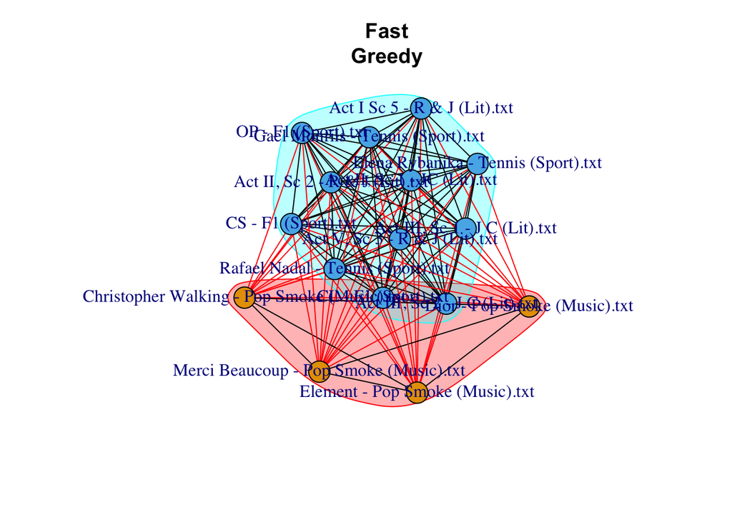

```r
set.seed(32014252) # keep community detection consistent
#identify community groups/clusters using cluster_fast_greedy()
cfg = cluster_fast_greedy(as.undirected(ByAbs))
g_cfg = plot(cfg,
             as.undirected(ByAbs),vertex.label=V(ByAbs)$role,main="Fast
Greedy")
```

```r
# Inspect the community membership
membership(cfg)
```

```
##                Act I Sc 5 - R & J (Lit).txt
##                                           2
##                 Act II, Sc 1 - JC (Lit).txt
##                                           2
##              Act II, Sc 2 - R & J (Lit).txt
##                                           2
##               Act III, Sc 1 - J C (Lit).txt
##                                           2
##               Act III, Sc 2 - J C (Lit).txt
##                                           2
##               Act V, Sc 3 - R & J (Lit).txt
##                                           2
## Christopher Walking - Pop Smoke (Music).txt
##                                           1
##                         CL - F1 (Sport).txt
##                                           2
##                         CS - F1 (Sport).txt
##                                           2
##                Dior - Pop Smoke (Music).txt
##                                           1
##             Element - Pop Smoke (Music).txt
##                                           1
##         Elena Rybanika - Tennis (Sport).txt
##                                           2
##           Gael Monfils - Tennis (Sport).txt
##                                           2
##      Merci Beaucoup - Pop Smoke (Music).txt
##                                           1
##                         OP - F1 (Sport).txt
##                                           2
##           Rafael Nadal - Tennis (Sport).txt
##                                           2
```

Here we can see that the fast greedy clustering algorithm has classified the nodes into 2 clusters, with all the songs being classified into group 1 and the remaining documents being classified into group 2. Accuracy wise, the algorithm was able to classify 1 of 3 groups which is an accuracy of 33%.

# Task 6: Tokens single-mode network (4 Marks)

### Creating the network

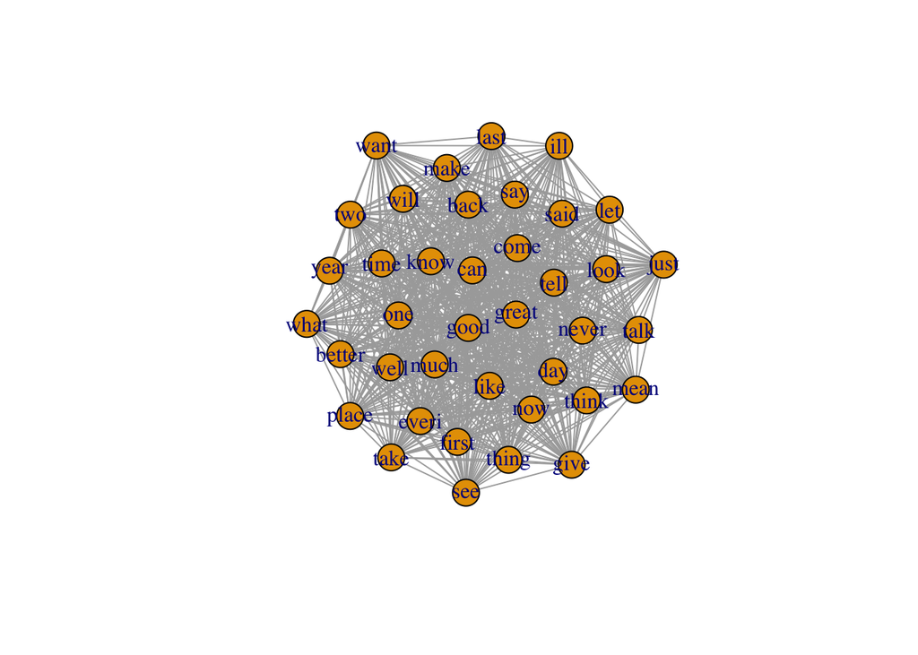

```r
# original dtm
dtmsx = as.matrix(dtms)

# convert to binary matrix
dtmsx = as.matrix((dtmsx > 0) + 0)

# multiply transpose binary matrix by binary matrix
ByTokenMatrix = t(dtmsx) %*% dtmsx

# make leading diagonal zero
diag(ByTokenMatrix) = 0

# create graph object
ByToken = graph_from_adjacency_matrix(ByTokenMatrix, mode = "undirected", weighted = TRUE)

set.seed(32014252) # keep clustering consistent
plot(ByToken) # plot
```

### Network Statistics

```r
# calculate network centrality measures and combine in a dataframe
b = as.table(betweenness(ByToken))
c = as.table(closeness(ByToken))
e = as.table(evcent(ByToken)$vector)

stats = as.data.frame(rbind(b,c,e))
stats = as.data.frame(t(stats))
colnames(stats) = c("betweenness", "closeness", "eigenvector")

averagePath = average.path.length(ByToken)
diameter = diameter(ByToken)

#sort and explore key nodes
stats[order(-stats$betweenness),]
```

```
##        betweenness   closeness eigenvector
## just           0.5 0.003676471   0.6383341
## can            0.0 0.002386635   0.9701848
## come           0.0 0.002320186   0.9981325
## day            0.0 0.003021148   0.7696722
## first          0.0 0.002583979   0.8974716
## give           0.0 0.003048780   0.7630093
## good           0.0 0.002386635   0.9701848
## great          0.0 0.002793296   0.8318799
## ill            0.0 0.003412969   0.6853341
## know           0.0 0.002320186   0.9981325
## last           0.0 0.003095975   0.7526593
## let            0.0 0.002840909   0.8221368
## like           0.0 0.002421308   0.9585070
## look           0.0 0.002717391   0.8567845
## make           0.0 0.002590674   0.8978671
## much           0.0 0.002583979   0.8974716
## now            0.0 0.002469136   0.9389416
## one            0.0 0.002392344   0.9687555
## place          0.0 0.003067485   0.7597823
## said           0.0 0.002570694   0.9038733
## say            0.0 0.002487562   0.9313890
## take           0.0 0.003076923   0.7587275
## tell           0.0 0.002314815   1.0000000
## thing          0.0 0.002793296   0.8323862
## think          0.0 0.002680965   0.8659777
## time           0.0 0.002570694   0.9018942
## two            0.0 0.003154574   0.7385175
## well           0.0 0.002583979   0.8974716
## what           0.0 0.003344482   0.6986293
## will           0.0 0.003021148   0.7701798
## year           0.0 0.003086420   0.7553823
## back           0.0 0.002785515   0.8337990
## better         0.0 0.003067485   0.7584629
## everi          0.0 0.003215434   0.7249703
## mean           0.0 0.003225806   0.7242390
## never          0.0 0.002570694   0.9036563
## see            0.0 0.003058104   0.7612007
## talk           0.0 0.003289474   0.7075131
## want           0.0 0.003690037   0.6363832
```

```r
stats[order(-stats$closeness),]
```

```
##        betweenness   closeness eigenvector
## want           0.0 0.003690037   0.6363832
## just           0.5 0.003676471   0.6383341
## ill            0.0 0.003412969   0.6853341
## what           0.0 0.003344482   0.6986293
## talk           0.0 0.003289474   0.7075131
## mean           0.0 0.003225806   0.7242390
## everi          0.0 0.003215434   0.7249703
## two            0.0 0.003154574   0.7385175
## last           0.0 0.003095975   0.7526593
## year           0.0 0.003086420   0.7553823
## take           0.0 0.003076923   0.7587275
## place          0.0 0.003067485   0.7597823
## better         0.0 0.003067485   0.7584629
## see            0.0 0.003058104   0.7612007
## give           0.0 0.003048780   0.7630093
## day            0.0 0.003021148   0.7696722
## will           0.0 0.003021148   0.7701798
## let            0.0 0.002840909   0.8221368
## great          0.0 0.002793296   0.8318799
## thing          0.0 0.002793296   0.8323862
## back           0.0 0.002785515   0.8337990
## look           0.0 0.002717391   0.8567845
## think          0.0 0.002680965   0.8659777
## make           0.0 0.002590674   0.8978671
## first          0.0 0.002583979   0.8974716
## much           0.0 0.002583979   0.8974716
## well           0.0 0.002583979   0.8974716
## said           0.0 0.002570694   0.9038733
## time           0.0 0.002570694   0.9018942
## never          0.0 0.002570694   0.9036563
## say            0.0 0.002487562   0.9313890
## now            0.0 0.002469136   0.9389416
## like           0.0 0.002421308   0.9585070
## one            0.0 0.002392344   0.9687555
## can            0.0 0.002386635   0.9701848
## good           0.0 0.002386635   0.9701848
## come           0.0 0.002320186   0.9981325
## know           0.0 0.002320186   0.9981325
## tell           0.0 0.002314815   1.0000000
```

```r
stats[order(-stats$eigenvector),]
```

```
##        betweenness   closeness eigenvector
## tell           0.0 0.002314815   1.0000000
## come           0.0 0.002320186   0.9981325
## know           0.0 0.002320186   0.9981325
## can            0.0 0.002386635   0.9701848
## good           0.0 0.002386635   0.9701848
## one            0.0 0.002392344   0.9687555
## like           0.0 0.002421308   0.9585070
## now            0.0 0.002469136   0.9389416
## say            0.0 0.002487562   0.9313890
## said           0.0 0.002570694   0.9038733
## never          0.0 0.002570694   0.9036563
## time           0.0 0.002570694   0.9018942
## make           0.0 0.002590674   0.8978671
## much           0.0 0.002583979   0.8974716
## well           0.0 0.002583979   0.8974716
## first          0.0 0.002583979   0.8974716
## think          0.0 0.002680965   0.8659777
## look           0.0 0.002717391   0.8567845
## back           0.0 0.002785515   0.8337990
## thing          0.0 0.002793296   0.8323862
## great          0.0 0.002793296   0.8318799
## let            0.0 0.002840909   0.8221368
## will           0.0 0.003021148   0.7701798
## day            0.0 0.003021148   0.7696722
## give           0.0 0.003048780   0.7630093
## see            0.0 0.003058104   0.7612007
## place          0.0 0.003067485   0.7597823
## take           0.0 0.003076923   0.7587275
## better         0.0 0.003067485   0.7584629
## year           0.0 0.003086420   0.7553823
## last           0.0 0.003095975   0.7526593
## two            0.0 0.003154574   0.7385175
## everi          0.0 0.003215434   0.7249703
## mean           0.0 0.003225806   0.7242390
## talk           0.0 0.003289474   0.7075131
## what           0.0 0.003344482   0.6986293
## ill            0.0 0.003412969   0.6853341
## just           0.5 0.003676471   0.6383341
## want           0.0 0.003690037   0.6363832
```

```r
print(stats, digits = 3)
```

```
##        betweenness closeness eigenvector
## can            0.0   0.00239       0.970
## come           0.0   0.00232       0.998
## day            0.0   0.00302       0.770
## first          0.0   0.00258       0.897
## give           0.0   0.00305       0.763
## good           0.0   0.00239       0.970
## great          0.0   0.00279       0.832
## ill            0.0   0.00341       0.685
## know           0.0   0.00232       0.998
## last           0.0   0.00310       0.753
## let            0.0   0.00284       0.822
## like           0.0   0.00242       0.959
## look           0.0   0.00272       0.857
## make           0.0   0.00259       0.898
## much           0.0   0.00258       0.897
## now            0.0   0.00247       0.939
## one            0.0   0.00239       0.969
## place          0.0   0.00307       0.760
## said           0.0   0.00257       0.904
## say            0.0   0.00249       0.931
## take           0.0   0.00308       0.759
## tell           0.0   0.00231       1.000
## thing          0.0   0.00279       0.832
## think          0.0   0.00268       0.866
## time           0.0   0.00257       0.902
## two            0.0   0.00315       0.739
## well           0.0   0.00258       0.897
## what           0.0   0.00334       0.699
## will           0.0   0.00302       0.770
## year           0.0   0.00309       0.755
## back           0.0   0.00279       0.834
## better         0.0   0.00307       0.758
## everi          0.0   0.00322       0.725
## mean           0.0   0.00323       0.724
## never          0.0   0.00257       0.904
## see            0.0   0.00306       0.761
## talk           0.0   0.00329       0.708
## want           0.0   0.00369       0.636
## just           0.5   0.00368       0.638
```

CENTRALITY MEASURES -

Overall, the network seems to have a certain level of interconnectedness, as indicated by the non-zero closeness centrality values, but lacks clear intermediaries in terms of betweenness centrality. The variation in eigenvector centrality values suggests differences in the importance or influence of tokens within the network.

```r
cat("Average Path Length: ", averagePath, "\nDiameter: ", diameter)
```

```
## Average Path Length:  9.426451
## Diameter:  15
```

Global Network Properties-

The average path length of 9.426451 indicates that, on average, it takes approximately 9.43 steps to navigate between any two nodes in the network. This suggests that the network is relatively dense and well-connected, as the average distance between nodes is relatively short.

The diameter of 15 indicates that the longest shortest path between any pair of nodes in the network is 15 steps. This suggests that the network is not overly spread out, as even the farthest nodes are relatively reachable within a moderate number of steps.

Overall, these global network properties suggest that the network has a dense and interconnected structure, with relatively short paths between most pairs of nodes.

### Community detection

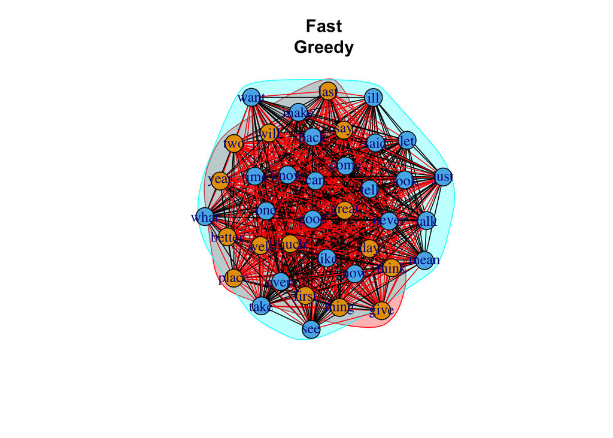

```r
set.seed(32014252) # keep clustering consistent
#identify community groups/clusters using cluster_fast_greedy()
cfg = cluster_fast_greedy(as.undirected(ByToken))

g_cfg = plot(cfg,
             as.undirected(ByToken),vertex.label=V(ByToken)$role,main="Fast
Greedy")
```

```r
# Inspect the community membership
membership(cfg)
```

```
##    can   come    day  first   give   good  great    ill   know   last    let
##      2      2      1      1      1      2      1      2      2      1      2
##   like   look   make   much    now    one  place   said    say   take   tell
##      2      2      2      1      2      2      1      2      1      2      2
##  thing  think   time    two   well   what   will   year   back better  everi
##      1      1      2      1      1      2      1      1      2      1      2
##   mean  never    see   talk   want   just
##      2      2      2      2      2      2
```

# Task 7: Bipartite (two-mode) network (4 Marks)

### Creating the network

```r
# formatting data for bipartite graph
dtmsa = as.data.frame(dtms) # clone dtms
dtmsa$ABS = rownames(dtmsa) # add row names
dtmsb = data.frame()

for (i in 1:nrow(dtmsa)){
    for (j in 1:(ncol(dtmsa)-1)){
        touse = cbind(dtmsa[i,j], dtmsa[i,ncol(dtmsa)], colnames(dtmsa[j]))
    dtmsb = rbind(dtmsb, touse ) # close loops
    }
  }

colnames(dtmsb) = c("weight", "abs", "token")
dtmsc = dtmsb[dtmsb$weight != 0,] # delete 0 weights

dtmsc = dtmsc[,c(2,3,1)]  # put colunms in order: abs, token, weight
```

### Plotting the graph

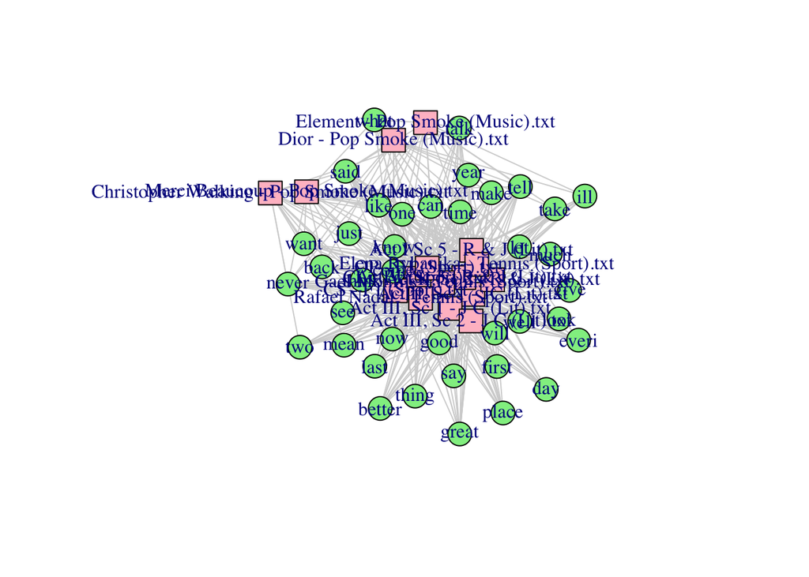

```r
set.seed(32014252) # keep plot consistent
# plotting bipartite graph
g <- graph.data.frame(dtmsc, directed=FALSE)
V(g)$type <- bipartite_mapping(g)$type
V(g)$color <- ifelse(V(g)$type, "lightgreen", "pink")
V(g)$shape <- ifelse(V(g)$type, "circle", "square")
E(g)$color <- "lightgray"
plot(g)
```

### Network Statistics

```r
# calculate network centrality measures and combine in a dataframe
d = as.table(degree(g))
b = as.table(betweenness(g))
c = as.table(closeness(g))
t = as.table(transitivity(g))

stats = as.data.frame(rbind(d, b, c, t))
stats = as.data.frame(t(stats))
colnames(stats) = c("degree", "betweenness", "closeness", "transitivity")

averagePath = average.path.length(g)
diameter = diameter(g)

#sort and explore key nodes
stats[order(-stats$betweenness),]
```

```
##                                             degree betweenness   closeness
## Merci Beaucoup - Pop Smoke (Music).txt          17 136.8788275 0.008064516
## Elena Rybanika - Tennis (Sport).txt             30 124.8822622 0.008196721
## Element - Pop Smoke (Music).txt                 17 122.7069606 0.008064516
## Gael Monfils - Tennis (Sport).txt               36  96.3125885 0.007518797
## Act II, Sc 2 - R & J (Lit).txt                  30  87.2505316 0.007692308
## Act I Sc 5 - R & J (Lit).txt                    30  86.9227168 0.007518797
## make                                            14  82.9570091 0.008264463
## OP - F1 (Sport).txt                             28  82.5832989 0.007692308
## Christopher Walking - Pop Smoke (Music).txt     16  79.9669111 0.007462687
## Act III, Sc 2 - J C (Lit).txt                   30  75.0314079 0.007042254
## Act II, Sc 1 - JC (Lit).txt                     36  73.9481713 0.007462687
## Act III, Sc 1 - J C (Lit).txt                   36  71.8220043 0.007751938
## Act V, Sc 3 - R & J (Lit).txt                   35  71.3700442 0.007812500
## said                                            14  61.6828647 0.008474576
## what                                            10  54.9413371 0.007812500
## two                                             10  50.1163952 0.007575758
## Dior - Pop Smoke (Music).txt                    14  43.8730028 0.007299270
## CS - F1 (Sport).txt                             33  41.5541834 0.007142857
## CL - F1 (Sport).txt                             39  39.4162954 0.006802721
## can                                             14  39.3871244 0.007692308
## ill                                             10  33.0194090 0.007518797
## great                                           11  27.8468700 0.007246377
## better                                          10  25.3463482 0.007518797
## place                                           10  25.0660837 0.006993007
## talk                                            10  22.3114740 0.007518797
## thing                                           11  18.5900348 0.006993007
## just                                            10  17.6425790 0.006802721
## take                                            11  17.4846527 0.006944444
## much                                            12  17.1942394 0.006802721
## now                                             14  16.8294892 0.007462687
## day                                             10  14.7225992 0.007194245
## time                                            13  13.2409105 0.006711409
## good                                            14  12.3445527 0.006369427
## want                                            10  11.7322644 0.007142857
## never                                           14   9.1707182 0.007407407
## Rafael Nadal - Tennis (Sport).txt               36   8.4625465 0.006250000
## tell                                            15   7.9944417 0.006849315
## one                                             15   6.1075539 0.007042254
## come                                            15   5.9081641 0.006896552
```

[output cut: 57 more lines]

```
## mean                                                   0
## let                                                    0
## last                                                   0
## year                                                   0
## give                                                   0
## look                                                   0
## see                                                    0
## think                                                  0
## first                                                  0
## like                                                   0
## know                                                   0
## well                                                   0
## will                                                   0
## back                                                   0
## everi                                                  0
```

```r
stats[order(-stats$closeness),]
```

```
##                                             degree betweenness   closeness
## said                                            14  61.6828647 0.008474576
## make                                            14  82.9570091 0.008264463
## Elena Rybanika - Tennis (Sport).txt             30 124.8822622 0.008196721
## Element - Pop Smoke (Music).txt                 17 122.7069606 0.008064516
## Merci Beaucoup - Pop Smoke (Music).txt          17 136.8788275 0.008064516
## Act V, Sc 3 - R & J (Lit).txt                   35  71.3700442 0.007812500
## what                                            10  54.9413371 0.007812500
## Act III, Sc 1 - J C (Lit).txt                   36  71.8220043 0.007751938
## Act II, Sc 2 - R & J (Lit).txt                  30  87.2505316 0.007692308
## OP - F1 (Sport).txt                             28  82.5832989 0.007692308
## can                                             14  39.3871244 0.007692308
## two                                             10  50.1163952 0.007575758
## Act I Sc 5 - R & J (Lit).txt                    30  86.9227168 0.007518797
## Gael Monfils - Tennis (Sport).txt               36  96.3125885 0.007518797
## ill                                             10  33.0194090 0.007518797
## better                                          10  25.3463482 0.007518797
## talk                                            10  22.3114740 0.007518797
## Act II, Sc 1 - JC (Lit).txt                     36  73.9481713 0.007462687
## Christopher Walking - Pop Smoke (Music).txt     16  79.9669111 0.007462687
## now                                             14  16.8294892 0.007462687
## never                                           14   9.1707182 0.007407407
## Dior - Pop Smoke (Music).txt                    14  43.8730028 0.007299270
## great                                           11  27.8468700 0.007246377
## day                                             10  14.7225992 0.007194245
## CS - F1 (Sport).txt                             33  41.5541834 0.007142857
## want                                            10  11.7322644 0.007142857
## Act III, Sc 2 - J C (Lit).txt                   30  75.0314079 0.007042254
## one                                             15   6.1075539 0.007042254
## place                                           10  25.0660837 0.006993007
## thing                                           11  18.5900348 0.006993007
## take                                            11  17.4846527 0.006944444
## come                                            15   5.9081641 0.006896552
## look                                            12   2.5734127 0.006896552
## tell                                            15   7.9944417 0.006849315
## CL - F1 (Sport).txt                             39  39.4162954 0.006802721
## much                                            12  17.1942394 0.006802721
## just                                            10  17.6425790 0.006802721
## time                                            13  13.2409105 0.006711409
## see                                             11   2.1232143 0.006666667
```

[output cut: 57 more lines]

```
## everi                                                  0
## good                                                   0
## say                                                    0
## Rafael Nadal - Tennis (Sport).txt                      0
## let                                                    0
## think                                                  0
## year                                                   0
## give                                                   0
## last                                                   0
## well                                                   0
## back                                                   0
## first                                                  0
## like                                                   0
## know                                                   0
## will                                                   0
```

```r
print(stats, digits = 3)
```

```
##                                             degree betweenness closeness
## Act I Sc 5 - R & J (Lit).txt                    30      86.923   0.00752
## Act II, Sc 1 - JC (Lit).txt                     36      73.948   0.00746
## Act II, Sc 2 - R & J (Lit).txt                  30      87.251   0.00769
## Act III, Sc 1 - J C (Lit).txt                   36      71.822   0.00775
## Act III, Sc 2 - J C (Lit).txt                   30      75.031   0.00704
## Act V, Sc 3 - R & J (Lit).txt                   35      71.370   0.00781
## Christopher Walking - Pop Smoke (Music).txt     16      79.967   0.00746
## CL - F1 (Sport).txt                             39      39.416   0.00680
## CS - F1 (Sport).txt                             33      41.554   0.00714
## Dior - Pop Smoke (Music).txt                    14      43.873   0.00730
## Element - Pop Smoke (Music).txt                 17     122.707   0.00806
## Elena Rybanika - Tennis (Sport).txt             30     124.882   0.00820
## Gael Monfils - Tennis (Sport).txt               36      96.313   0.00752
## Merci Beaucoup - Pop Smoke (Music).txt          17     136.879   0.00806
## OP - F1 (Sport).txt                             28      82.583   0.00769
## Rafael Nadal - Tennis (Sport).txt               36       8.463   0.00625
## can                                             14      39.387   0.00769
## come                                            15       5.908   0.00690
## day                                             10      14.723   0.00719
## first                                           12       0.667   0.00585
## give                                            10       3.055   0.00595
## good                                            14      12.345   0.00637
## great                                           11      27.847   0.00725
## ill                                             10      33.019   0.00752
## know                                            15       0.000   0.00459
## last                                            10       3.260   0.00595
## let                                             12       4.588   0.00625
## like                                            15       0.300   0.00552
## look                                            12       2.573   0.00690
## make                                            14      82.957   0.00826
## much                                            12      17.194   0.00680
## now                                             14      16.829   0.00746
## one                                             15       6.108   0.00704
## place                                           10      25.066   0.00699
## said                                            14      61.683   0.00847
## say                                             13       4.651   0.00633
## take                                            11      17.485   0.00694
## tell                                            15       7.994   0.00685
## thing                                           11      18.590   0.00699
```

[output cut: 57 more lines]

```
## time                                                   0
## two                                                    0
## well                                                   0
## what                                                   0
## will                                                   0
## year                                                   0
## back                                                   0
## better                                                 0
## everi                                                  0
## mean                                                   0
## never                                                  0
## see                                                    0
## talk                                                   0
## want                                                   0
## just                                                   0
```

Conversely, the node “will” has a degree of 10, a betweenness centrality of 0, and a closeness centrality of 0.00295 This indicates that “will” has fewer connections, does not lie on many shortest paths between other nodes, and is relatively distant from other nodes in the network.

We can also observe that the transitivity is 0, which means there are no such triangles in the graph, implying a lack of clustering or transitive relationships.

```r
cat("Average Path Length: ", averagePath, "\nDiameter: ", diameter)
```

```
## Average Path Length:  2.745455
## Diameter:  8
```

The average path length of 2.745455 indicates that, on average, nodes in the network are relatively close to each other, requiring just under three steps to reach one another. This suggests a relatively efficient communication or information flow within the network.

The diameter of 8 indicates the longest shortest path between any two nodes in the network. While the average path length is relatively low, the diameter suggests that there may be some pairs of nodes that are more distant from each other, requiring up to 8 steps to reach one another. This could imply certain pockets or clusters of nodes that are less directly connected to each other.